# code_kindle_text

Serdar Korur

12/13/2019

Here is the code related to my medium post at:

https://towardsdatascience.com/an-accidental-side-effect-of-text-mining-4b43f8ee1273

As I read on my kindle I highlight the passages that I like so that I can re-read them later.

These annotations are stored on my Kindle and are backed up at Amazon. And after some time, they started to accumulate and became some kind of data.

I came up with an idea to analyze all those text I highlighted to figure out what kind of content I was most likely to highlight.

The plan was to use text mining and sentiment analysis, generate insights and compare them to my real opinions of those books. So I can have the first-hand test of how useful text mining is. With that knowledge, I can be more convinced when I apply the method to a business problem.

```r
# Use readLines function to parse the text file
getwd()
```

```
## [1] "C:/Users/serda/Documents/workingdirectory/textmining/textmining_github"
```

```r
highlights <- readLines("Kindle_highlights_Serdar.Rmd", encoding = "UTF-8")

# Create a dataframe where each row is a line from the text

df <- data.frame(highlights)

# Packages

library(tidyverse)   # includes ggplot2, dplyr, tidyr, readr, purrr, tibble, stringr, forcats
library(tidytext)
library(wordcloud2)
```

```r
data(stop_words)

# print every 50th word

stop_words_small <- stop_words[seq(1, nrow(stop_words), 50),]

stop_words_small %>% print(n=50)
```

```
## # A tibble: 23 x 2
##    word       lexicon
##    <chr>      <chr>
##  1 a          SMART
##  2 at         SMART
##  3 contain    SMART
##  4 few        SMART
##  5 hers       SMART
##  6 last       SMART
##  7 nine       SMART
##  8 presumably SMART
##  9 some       SMART
## 10 they'd     SMART
## 11 very       SMART
## 12 without    SMART
## 13 what       snowball
## 14 they'll    snowball
## 15 during     snowball
## 16 again      onix
## 17 but        onix
## 18 finds      onix
## 19 if         onix
## 20 much       onix
## 21 parted     onix
## 22 since      onix
## 23 under      onix
```

```r
df$highlights <- str_replace_all(df$highlights, "’", "'")
```

Now, the text is ready for the frequency analysis. Words in a text mining project are called tokens. We can split the text into single words by unnest_tokens() function from tidytext package, filter the stop_words and count.

```r
df <- df %>% unnest_tokens(word, highlights) %>%
             anti_join(stop_words) %>%
             filter(!word %in% c("highlights","highlight", "page",
                      "location", "yellow", "pink", "orange", "blue"))
```

```r
top_kindle_highlights <- df %>%
 group_by(word) %>%
 count() %>%
 arrange(desc(n))
```

**10 most frequent words from my kindle highlights.**

```r
top_kindle_highlights
```

```
## # A tibble: 12,433 x 2
## # Groups:   word [12,433]
##    word       n
##    <chr>  <int>
##  1 people   592
##  2 story    340
##  3 life     318
##  4 time     309
##  5 mind     213
##  6 change   212
##  7 feel     211
##  8 world    171
##  9 person   170
## 10 habits   157
## # ... with 12,423 more rows
```

Wordclouds are a good alternative to long lists of words for visualizing text data. Wordcloud2 package allows you to use any image as the markup.

```r
wordcloud2(top_kindle_highlights, figPath = bat, size = 1, backgroundColor = "white", color = color_vector(data$freq) )
```

[output not shown]

**Bigram Analysis**

Single words are a good starting point what the books were about. **But they are not very informative without context.** Frequency analysis can also be performed to measure how often pairs of two words **(bigrams)** occur in the text. This allows us to capture finer details in the text.

To do this he combined the unnested single tokens which is isolated above back into a continuous text and then performed bigram analysis. You can use **str_c()** function from stringr package to concatenate the single words.

```r
# Recreate the df
df <- data.frame(highlights)
df$highlights <- str_replace_all(df$highlights, "’", "'")

df <- df %>% unnest_tokens(word, highlights) %>%
  anti_join(stop_words) %>%
 filter(!word %in% c("highlights","highlight", "page",
                      "location", "yellow", "pink", "orange", "blue",
                      "export", "hidden", "truncated", "kindle", "note", "limits"))

df_com <- str_c(df$word, " ")
df_com <- data.frame(df_com)
```

Let’s split the text into bigrams and count the most common two word pairs.

```r
df_bigram <- df_com %>%
 unnest_tokens(bigram, df_com, token = "ngrams",
 n = 3, n_min = 2)
top_bigrams <- df_bigram %>%
 group_by(bigram) %>%
 count() %>%
 arrange(desc(n))%>%
 print(n=20)
```

```
## # A tibble: 107,317 x 2
## # Groups:   bigram [107,317]
##    bigram                    n
##    <chr>                 <int>
##  1 body language            30
##  2 behavior change          23
##  3 crucial conversations    19
##  4 fixed mindset            19
##  5 growth mindset           19
##  6 subconscious mind        19
##  7 told story               18
##  8 type person              17
##  9 object desire            16
## 10 system 1                 16
## 11 pay attention            15
## 12 bad habits               13
## 13 law behavior             13
## 14 law behavior change      13
## 15 social media             13
## 16 inciting incident        12
## 17 people feel              12
## 18 subject matter           12
## 19 human nature             11
## 20 objective criteria       11
## # ... with 1.073e+05 more rows
```

```r
# And visualize them on a plot

top <- top_bigrams[1:25,]
```

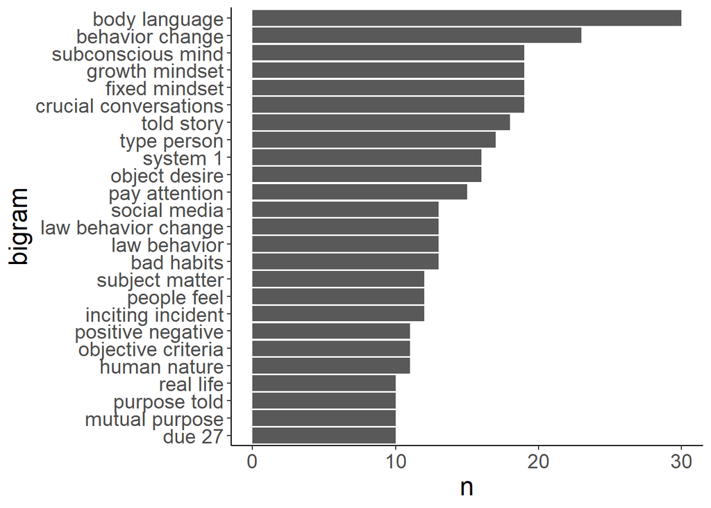

```r
top %>% ungroup() %>% mutate(bigram = fct_reorder(bigram, n)) %>%
 ggplot(aes(x=bigram, y=n)) +
 geom_col() +
 coord_flip() +
 theme_classic() +
 theme(legend.position = "none",
 text = element_text(size=18))
```

For example, if you go back above in the top 10 most frequent words table 6th word was change. But we didn’t know what the change was about. And here we see that one of the most common bigram is behavioral change. It is making more sense. But it can improve to look at each book individually.

We can also do what we did for the whole document for highlights from single books.

But how can we capture them individually?

Let’s first look at the text once more. Before each book **“Your Kindle Notes For:”** appears.

Let’s find out the line numbers for the beginning and the end of each book and use those indexes for fishing out each book.

We will reuse the data frame df we created above. **str_which()** function returns index numbers of the lines which contain a given pattern. In the last step, capturing the text between two consecutive indexes will give us the book between them.

```r
# Since I modified df above. I will recreate it again.
df <- data.frame(highlights)
df$highlights <- str_replace_all(df$highlights, "’", "'")

# Getting the index number for each book

indexes <- str_which(df$highlights, pattern = fixed("Your Kindle Notes For"))
book_names <- df$highlights[indexes + 1]
indexes <-  c(indexes,nrow(df))

# Create an empty list

books <- list()

# Now the trick. Capture each 28 book separately in a list.

for(i in 1:(length(indexes)-1)) {
    books[[i]] <- data.frame(df$highlights[(indexes[i]:indexes[i+1]-1)])
    colnames(books[[i]]) <- "word_column"
    books[[i]]$word_column <- as.character(books[[i]]$word_column)
}
```

Let’s check whether it worked, for example you can look up the 5th book on our list.

```r
head(books[[5]])
```

```
##                                           word_column
## 1
## 2                              Your Kindle Notes For:
## 3 Bird by Bird: Some Instructions on Writing and Life
## 4                                         Anne Lamott
## 5             Last accessed on Saturday July 27, 2019
## 6                         75 Highlight(s) | 4 Note(s)
```

```r
head(books[[15]])
```

```
##                                                  word_column
## 1
## 2                                     Your Kindle Notes For:
## 3 Getting to Yes: Negotiating an agreement without giving in
## 4                               Roger Fisher and William Ury
## 5                 Last accessed on Saturday November 3, 2018
## 6                               266 Highlight(s) | 3 Note(s)
```

Now, we have the individual books captured. I will repeat the procedure we used to analyse the whole text above to analyze each of the 28 books by using a for loop.

```r
top <- list()
for(i in 1:28){
books[[i]] <- books[[i]] %>% unnest_tokens(word, word_column) %>%
             anti_join(stop_words) %>%
             filter(!word %in% c("highlights","highlight", "page",
                      "location", "yellow", "pink", "orange", "blue",
                      "export", "hidden", "truncated", "kindle", "note", "limits"))

# Find out the top words in each book and capture them in a list (top)

top[[i]] <- books[[i]] %>%
              group_by(word) %>%
              count() %>%
              arrange(desc(n))
}
for(i in 1:28){
  print(book_names[[i]])
  print(top[[i]])
}
```

```
## [1] "Thinking, Fast and Slow"
## # A tibble: 1,619 x 2
## # Groups:   word [1,619]
##    word          n
##    <chr>     <int>
##  1 people       33
##  2 system       26
##  3 1            18
##  4 mind         18
##  5 effect       17
##  6 bad          15
##  7 cognitive    15
##  8 ease         15
##  9 theory       13
## 10 decision     12
## # ... with 1,609 more rows
## [1] "Influence: The Psychology of Persuasion (Collins Business Essentials)"
## # A tibble: 278 x 2
## # Groups:   word [278]
##    word            n
##    <chr>       <int>
##  1 142             5
##  2 146             5
##  3 131             3
##  4 147             3
##  5 154             3
##  6 179             3
##  7 association     3
##  8 food            3
##  9 information     3
## 10 people          3
## # ... with 268 more rows
## [1] "On Writing Well, 30th Anniversary Edition: An Informal Guide to Writing Nonfiction"
## # A tibble: 770 x 2
## # Groups:   word [770]
##    word         n
##    <chr>    <int>
##  1 writing     26
##  2 write       18
##  3 sentence    15
```

[output cut: 393 more lines]

```
## # A tibble: 570 x 2
## # Groups:   word [570]
##    word              n
##    <chr>         <int>
##  1 people           14
##  2 product           8
##  3 opportunities     7
##  4 person            7
##  5 start             7
##  6 assets            6
##  7 job               6
##  8 time              6
##  9 138               5
## 10 create            5
## # ... with 560 more rows
```

Now, looking at the frequent words from each book we can get more insights what they are about.

The bigrams for the same books.

```r
df <- data.frame(highlights)
df$highlights <- str_replace_all(df$highlights, "’", "'")

# Getting the index number for each book

indexes <- str_which(df$highlights, pattern = fixed("Your Kindle Notes For"))
book_names <- df$highlights[indexes + 1]
indexes <-  c(indexes,nrow(df))

# Capturing each book individually

books <- list()
for (i in 1:(length(indexes)-1)) {
    books[[i]] <- data.frame(df$highlights[(indexes[i]:indexes[i+1]-1)])
    colnames(books[[i]]) <- "word_column"
    books[[i]]$word_column <- as.character(books[[i]]$word_column)
}

# Next step in the plan was splitting the text into single words by unnest_tokens function.



for(i in 1:28){
books[[i]] <- books[[i]] %>% unnest_tokens(word, word_column) %>%
             anti_join(stop_words) %>%
             filter(!word %in% c("highlights","highlight", "page",
                      "location", "yellow", "pink", "orange", "blue",
                      "export", "hidden", "truncated", "kindle", "note", "limits"))
}

# After this preparation step I can combine the single words back into a continous text

for(i in 1:28){
books[[i]] <- str_c(books[[i]]$word, " ")
books[[i]] <- data.frame(books[[i]])
}


df_bigram <- list()

for(i in 1:28){
df_bigram[[i]] <- books[[i]] %>%
       unnest_tokens(bigram, books..i.., token = "ngrams",
                                     n = 3, n_min = 2)
}

for (i in 1:28){
  print(book_names[i])
df_bigram[[i]] %>%
  group_by(bigram) %>%
  count() %>%
  arrange(desc(n))%>%
  print(n=10)

}
```

```
## [1] "Thinking, Fast and Slow"
## # A tibble: 5,768 x 2
## # Groups:   bigram [5,768]
##    bigram                    n
##    <chr>                 <int>
##  1 system 1                 16
##  2 cognitive ease            9
##  3 system 2                  8
##  4 halo effect               4
##  5 loss aversion             4
##  6 possibility effect        4
##  7 affective forecasting     3
##  8 availability bias         3
##  9 cognitive strain          3
## 10 decision weights          3
## # ... with 5,758 more rows
## [1] "Influence: The Psychology of Persuasion (Collins Business Essentials)"
## # A tibble: 673 x 2
## # Groups:   bigram [673]
##    bigram                    n
##    <chr>                 <int>
##  1 association principle     2
##  2 click whirr               2
##  3 click whirr response      2
##  4 luncheon technique        2
##  5 reciprocity rule          2
##  6 whirr response            2
##  7 0 13                      1
##  8 0 13 rule                 1
##  9 13 rule                   1
## 10 13 rule reciprocation     1
## # ... with 663 more rows
## [1] "On Writing Well, 30th Anniversary Edition: An Informal Guide to Writing Nonfiction"
## # A tibble: 2,172 x 2
## # Groups:   bigram [2,172]
##    bigram                       n
##    <chr>                    <int>
##  1 500th appendix               2
##  2 choice unity                 2
##  3 confronted solved            2
```

[output cut: 393 more lines]

```
## # A tibble: 1,611 x 2
## # Groups:   bigram [1,611]
##    bigram                 n
##    <chr>              <int>
##  1 product management     3
##  2 faster cheaper         2
##  3 skills experiences     2
##  4 soft assets            2
##  5 weak ties              2
##  6 0 15                   1
##  7 0 15 paranoid          1
##  8 101 business           1
##  9 101 business crazy     1
## 10 101 inspired           1
## # ... with 1,601 more rows
```

If you want to see another example of this capturing process you can have a look at my recent post [here](https://dataatomic.com/r/data-wrangling-text-mining/).

Looking at each book individually, he started to be more and more obsessed about the books in my kindle. He decided to order a couple of them.

**Sentiment analysis** is used to evaluate emotional charge in a text mining project. Most common uses are social media monitoring, customer experience management, and Voice of Customer, to understand how they feel.

The **bing** lexicon categorizes words into positive and negative categories, in a binary fashion. The **nrc** lexicon uses categories of positive, negative, anger, anticipation, disgust, fear, joy, sadness, surprise, and trust.

**Using bing lexicon**

Here is how R produced the above plot:

```r
df <- data.frame(highlights)
df$highlights <- str_replace_all(df$highlights, "’", "'")
df <- df %>% unnest_tokens(word, highlights) %>%
  anti_join(stop_words) %>%
 filter(!word %in% c("highlights","highlight", "page",
                      "location", "yellow", "pink", "orange", "blue",
                      "export", "hidden", "truncated", "kindle", "note", "limits"))

bing_word_counts <- df %>% inner_join(get_sentiments("bing")) %>%
  count(word, sentiment, sort = TRUE) %>%
  ungroup()

bing_word_counts
```

```
## # A tibble: 1,854 x 3
##    word      sentiment     n
##    <chr>     <chr>     <int>
##  1 bad       negative     93
##  2 success   positive     91
##  3 hard      negative     85
##  4 love      positive     69
##  5 difficult negative     63
##  6 negative  negative     63
##  7 easy      positive     62
##  8 fear      negative     62
##  9 wrong     negative     62
## 10 positive  positive     58
## # ... with 1,844 more rows
```

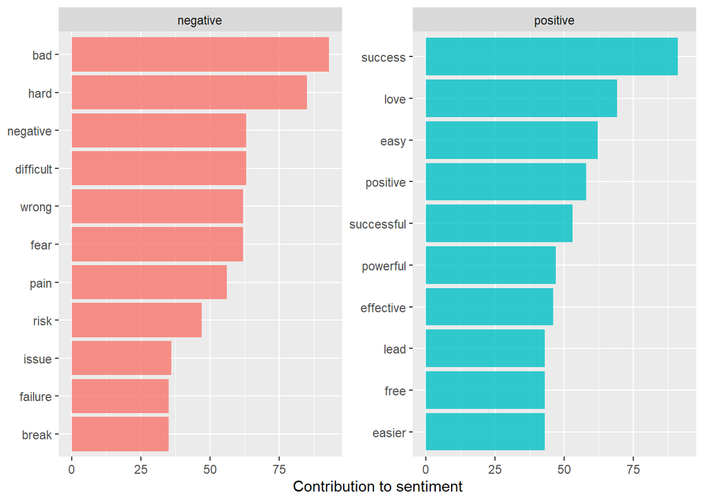

```r
# Top contributors to positive and negative sentiment


bing <- bing_word_counts %>%
  group_by(sentiment) %>%
  top_n(10) %>%
  ggplot(aes(reorder(word, n), n, fill=sentiment)) +
  geom_bar(alpha=0.8, stat="identity", show.legend = FALSE)+
  facet_wrap(~sentiment, scales = "free_y") +
  labs(y= "Contribution to sentiment", x = NULL) +
  coord_flip()
bing
```

**Using nrc lexion**

We see that I am more likely to highlight if a text is charged with positive rather than negative sentiment, and individually trust, anticipation and joy rather than fear and sadness.

```r
df <- data.frame(highlights)
df$highlights <- str_replace_all(df$highlights, "’", "'")
df <- df %>% unnest_tokens(word, highlights) %>%
  anti_join(stop_words) %>%
 filter(!word %in% c("highlights","highlight", "page",
                      "location", "yellow", "pink", "orange", "blue",
                      "export", "hidden", "truncated", "kindle", "note", "limits"))
sentiment <- df %>%
        left_join(get_sentiments("nrc")) %>%
        filter(!is.na(sentiment)) %>%
        count(sentiment, sort = TRUE)
sentiment
```

```
## # A tibble: 10 x 2
##    sentiment        n
##    <chr>        <int>
##  1 positive      8326
##  2 trust         4165
##  3 negative      3860
##  4 anticipation  3366
##  5 joy           2642
##  6 fear          2446
##  7 sadness       1844
##  8 anger         1799
##  9 surprise      1339
## 10 disgust       1093
```

**Normalized sentiments**

One important thing to add, since each emotion category has different number of words in a language. Emotional categories with less words are less likely to appear in a given text. Thus, I would like to normalize them according to their numbers in the lexicon and see how it differs than the above results.

```r
# I will add numbers of each categories from the NRC lexicon

lexicon <- c(2317, 3338, 1234, 842, 1483, 691, 1250, 1195, 1060, 535)
polarity <-  c(1,1,1,1,1,0,0,0,0,0)
sentiment <- data.frame(sentiment, lexicon)
norm_sentiment <- sentiment %>% mutate( normalized = n/lexicon) %>% arrange(desc(normalized))
sentiment <- data.frame(norm_sentiment, polarity)
sentiment
```

```
##       sentiment    n lexicon normalized polarity
## 1  anticipation 3366     842   3.997625        1
## 2      positive 8326    2317   3.593440        1
## 3          fear 2446     691   3.539797        1
## 4      negative 3860    1234   3.128039        1
## 5       disgust 1093     535   2.042991        1
## 6           joy 2642    1483   1.781524        0
## 7         anger 1799    1195   1.505439        0
## 8       sadness 1844    1250   1.475200        0
## 9      surprise 1339    1060   1.263208        0
## 10        trust 4165    3338   1.247753        0
```

```r
# General findings

sentiment %>% group_by(polarity) %>% summarize(n2 = sum(lexicon))
```

```
## # A tibble: 2 x 2
##   polarity    n2
##      <dbl> <dbl>
## 1        0  8326
## 2        1  5619
```

Now, **anticipation** is the highest emotion found in the text that I highlighted. This does not seem a coincidence to me. Since most of the books in our analysis is about productivity and self-development. The productivity tips and tools usually contain words associated with anticipation.

In a similar way, I can look at the sentiment for individual books

```r
df <- data.frame(highlights)

# Kindle uses apostrophes (’), but stop_words uses sigle quotes (')
# To be able to use all stop_words I should replace apostrophes with quotes
df$highlights <- str_replace_all(df$highlights, "’", "'")

# Getting the index number for each book

indexes <- str_which(df$highlights, pattern = fixed("Your Kindle Notes For"))
book_names <- df$highlights[indexes + 1]
indexes <-  c(indexes,nrow(df))

# Capturing each book individually

books <- list()
for (i in 1:(length(indexes)-1)) {
    books[[i]] <- data.frame(df$highlights[(indexes[i]:indexes[i+1]-1)])
    colnames(books[[i]]) <- "word_column"
    books[[i]]$word_column <- as.character(books[[i]]$word_column)
}

# Next step in the plan was splitting the text into single words by unnest_tokens function.


for(i in 1:28){
books[[i]] <- books[[i]] %>% unnest_tokens(word, word_column) %>%
             anti_join(stop_words) %>%
             filter(!word %in% c("highlights","highlight", "page",
                      "location", "yellow", "pink", "orange", "blue"))
}

sentiment <- list()
for (i in 1:28){
sentiment[[i]] <- books[[i]] %>%
        left_join(get_sentiments("nrc")) %>%
        filter(!is.na(sentiment)) %>%
        count(sentiment, sort = TRUE)
        print(book_names[i])
        print(sentiment[[i]])
}
```

```
## [1] "Thinking, Fast and Slow"
## # A tibble: 10 x 2
##    sentiment        n
##    <chr>        <int>
##  1 positive       450
##  2 trust          256
##  3 negative       254
##  4 anticipation   163
##  5 fear           153
##  6 sadness        116
##  7 joy            107
##  8 anger          104
##  9 disgust         81
## 10 surprise        75
## [1] "Influence: The Psychology of Persuasion (Collins Business Essentials)"
```

[output cut: 374 more lines]

```r
for (i in 1:28){
sentiment[[i]] %>%
    filter(sentiment %in% c('positive','negative')) %>%
    mutate( n2 = n/sum(n)) %>% print()
  }
```

```
## # A tibble: 2 x 3
##   sentiment     n    n2
##   <chr>     <int> <dbl>
## 1 positive    450 0.639
## 2 negative    254 0.361
## # A tibble: 2 x 3
##   sentiment     n    n2
##   <chr>     <int> <dbl>
## 1 positive     53 0.779
## 2 negative     15 0.221
## # A tibble: 2 x 3
##   sentiment     n    n2
##   <chr>     <int> <dbl>
## 1 positive    172 0.637
## 2 negative     98 0.363
## # A tibble: 2 x 3
##   sentiment     n    n2
##   <chr>     <int> <dbl>
## 1 positive    413 0.677
## 2 negative    197 0.323
## # A tibble: 2 x 3
##   sentiment     n    n2
##   <chr>     <int> <dbl>
## 1 positive     77 0.583
## 2 negative     55 0.417
## # A tibble: 2 x 3
##   sentiment     n    n2
##   <chr>     <int> <dbl>
## 1 positive    835 0.701
## 2 negative    356 0.299
## # A tibble: 2 x 3
##   sentiment     n    n2
##   <chr>     <int> <dbl>
## 1 positive    860 0.703
## 2 negative    364 0.297
## # A tibble: 2 x 3
##   sentiment     n    n2
##   <chr>     <int> <dbl>
## 1 positive    758 0.604
## 2 negative    496 0.396
```

[output cut: 84 more lines]

```
## 2 negative     59 0.244
## # A tibble: 2 x 3
##   sentiment     n    n2
##   <chr>     <int> <dbl>
## 1 positive    206 0.680
## 2 negative     97 0.320
## # A tibble: 1 x 3
##   sentiment     n    n2
##   <chr>     <int> <dbl>
## 1 positive     24     1
## # A tibble: 2 x 3
##   sentiment     n    n2
##   <chr>     <int> <dbl>
## 1 positive    145 0.784
## 2 negative     40 0.216
```

```r
books <- str_trunc(book_names, width=22)
all <- list()
for (i in 1:28) {
all[[i]] <- sentiment[[i]] %>% filter(sentiment %in% c('positive','negative')) %>% mutate(n2 = n/sum(n)) %>% print()
}
```

```
## # A tibble: 2 x 3
##   sentiment     n    n2
##   <chr>     <int> <dbl>
## 1 positive    450 0.639
## 2 negative    254 0.361
## # A tibble: 2 x 3
##   sentiment     n    n2
##   <chr>     <int> <dbl>
## 1 positive     53 0.779
## 2 negative     15 0.221
## # A tibble: 2 x 3
##   sentiment     n    n2
##   <chr>     <int> <dbl>
## 1 positive    172 0.637
## 2 negative     98 0.363
## # A tibble: 2 x 3
##   sentiment     n    n2
##   <chr>     <int> <dbl>
## 1 positive    413 0.677
## 2 negative    197 0.323
## # A tibble: 2 x 3
##   sentiment     n    n2
##   <chr>     <int> <dbl>
## 1 positive     77 0.583
## 2 negative     55 0.417
## # A tibble: 2 x 3
##   sentiment     n    n2
##   <chr>     <int> <dbl>
## 1 positive    835 0.701
## 2 negative    356 0.299
## # A tibble: 2 x 3
##   sentiment     n    n2
##   <chr>     <int> <dbl>
## 1 positive    860 0.703
## 2 negative    364 0.297
## # A tibble: 2 x 3
##   sentiment     n    n2
##   <chr>     <int> <dbl>
## 1 positive    758 0.604
## 2 negative    496 0.396
```

[output cut: 84 more lines]

```
## 2 negative     59 0.244
## # A tibble: 2 x 3
##   sentiment     n    n2
##   <chr>     <int> <dbl>
## 1 positive    206 0.680
## 2 negative     97 0.320
## # A tibble: 1 x 3
##   sentiment     n    n2
##   <chr>     <int> <dbl>
## 1 positive     24     1
## # A tibble: 2 x 3
##   sentiment     n    n2
##   <chr>     <int> <dbl>
## 1 positive    145 0.784
## 2 negative     40 0.216
```

Positivty Map of the books.

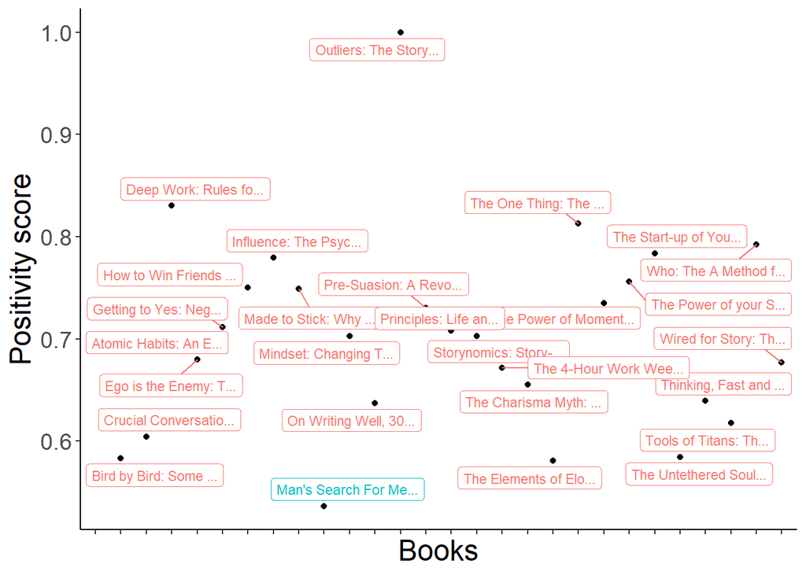

```r
all_bound <- do.call("rbind", all) %>% filter(sentiment == "positive")

library(ggrepel)
all_bound %>% ggplot(aes(x= book_names, y=n2)) +
  geom_point() +
  geom_label_repel(aes(label=books, color = ifelse(n2 <0.55, "red", "blue")), size = 3) +
  theme_classic() +
  theme(legend.position = "none",
        text = element_text(size=18),
        axis.text.x = element_blank()) +
  xlab("Books") +
  ylab("Positivity score")
```

The lowest positivity score was found in the book **“Man’s search for meaning”.** This is also kind of expected. Since the book is based on Victor Frankl sufferings during the second world war.

Let’s look at the word count in our Outlier.

```r
book_names[[27]]
```

```
## [1] "Outliers: The Story of Success"
```

```r
top[[27]]
```

```
## # A tibble: 105 x 2
## # Groups:   word [105]
##    word             n
##    <chr>        <int>
##  1 ability          3
##  2 knowing          3
##  3 sense            3
##  4 communicate      2
##  5 distance         2
##  6 family           2
##  7 intelligence     2
##  8 power            2
##  9 practical        2
## 10 sternberg        2
## # ... with 95 more rows
```

…

### Summary

It is not feasible to read millions of pages to check whether text mining is reliable. But here I got some data that I know the content and I applied text mining approaches and sentiment analysis. Both the monograms or bigrams pointed to similar ideas what the books were about. And the sentiments made sense with the genres of the books in my kindle.